# Logistic regression - player’s bets

jraiskin

Thu Aug 17 16:14:08 2017

# Load data and import libraries

```r
library(psych)  # describe, additional statistics
library(ROCR)  # ROC curve
library(corrplot)  # plot correlation matrix

# set working directory
work_dir <- switch(Sys.info()[["user"]],
             'Yarden-' = 'D:/Python_env/betting_player_response')
stopifnot(dir.exists(work_dir))
setwd(work_dir)

# set file names and paths
data_dir <- 'data'
output_dir <- 'outputs'
utils_dir <- 'utils'
raw_data_fname <- 'class_prob_data.RData'
raw_data_path <- file.path(data_dir, raw_data_fname)

load(raw_data_path)  # loaded as DATA_1
```

```r
# some basic descriptives
str(DATA_1)
```

```
## 'data.frame':    570170 obs. of  11 variables:
##  $ TimeStamp                   : POSIXct, format: "2015-09-11 01:37:20" "2015-09-11 01:37:33" ...
##  $ Time_from_first_spin_seconds: int  0 13 18 23 28 33 39 64 69 75 ...
##  $ PlatformID                  : int  3 3 3 3 3 3 3 3 3 3 ...
##  $ GameID                      : int  63 63 63 63 63 63 63 63 63 63 ...
##  $ Startbalance                : num  1000 992 985 978 970 ...
##  $ EndBalance                  : num  992 985 978 970 962 ...
##  $ MBetsAmount                 : num  7.5 7.5 7.5 7.5 7.5 7.5 7.5 7.5 7.5 7.5 ...
##  $ MWInsAmount                 : num  0 0 0 0 0 0 1.25 0 12.5 37.5 ...
##  $ IND_USER_ID                 : int  1 1 1 1 1 1 1 1 1 1 ...
##  $ LABELS                      : Factor w/ 2 levels "0","1": 1 1 1 1 1 1 1 1 1 1 ...
##  $ V_1                         : num  1.13 2.63 1.96 2.28 7.14 ...
```

It seems that we have some factors that are encoded as ints.

We also have a stime variable, `TimeStamp`.

```r
#### descriptive statisttics ####
# change types to factors
factor_column_names <- c('PlatformID', 'GameID', 'IND_USER_ID')
for (column in factor_column_names){
  DATA_1[, column] <- as.factor(DATA_1[, column])
}

# look for missing values => none found
DATA_1[!complete.cases(DATA_1),]
```

```
##  [1] TimeStamp                    Time_from_first_spin_seconds
##  [3] PlatformID                   GameID
##  [5] Startbalance                 EndBalance
##  [7] MBetsAmount                  MWInsAmount
##  [9] IND_USER_ID                  LABELS
## [11] V_1
## <0 rows> (or 0-length row.names)
```

```r
# have a look again (visualization is not straight forward)
summary(DATA_1)
```

```
##    TimeStamp                   Time_from_first_spin_seconds
##  Min.   :2015-09-05 03:00:28   Min.   :    0
##  1st Qu.:2015-09-05 05:08:54   1st Qu.:  549
##  Median :2015-09-05 06:43:28   Median : 1629
##  Mean   :2015-09-05 09:35:41   Mean   :13794
##  3rd Qu.:2015-09-05 08:32:33   3rd Qu.:10197
##  Max.   :2015-09-14 00:07:45   Max.   :86399
##
##    PlatformID         GameID        Startbalance       EndBalance
##  5      :221923   63     :289343   Min.   :      3   Min.   :      0
##  3      : 92193   128    : 57119   1st Qu.:    925   1st Qu.:    920
##  2      : 75564   89     : 41931   Median :   1284   Median :   1285
##  6      : 74246   104    : 32211   Mean   :   5153   Mean   :   5151
##  1      : 64450   121    : 29595   3rd Qu.:   2915   3rd Qu.:   2918
##  8      : 28750   5026   : 28680   Max.   :2003408   Max.   :2003408
##  (Other): 13044   (Other): 91291
##   MBetsAmount        MWInsAmount        IND_USER_ID     LABELS
##  Min.   :    0.00   Min.   :0.00e+00   1275   :  1993   0:235923
##  1st Qu.:   10.00   1st Qu.:0.00e+00   1826   :  1803   1:334247
##  Median :   25.00   Median :0.00e+00   1612   :  1683
##  Mean   :   65.75   Mean   :5.98e+01   546    :  1653
##  3rd Qu.:   40.00   3rd Qu.:3.00e+00   1091   :  1620
##  Max.   :30000.00   Max.   :1.35e+06   2964   :  1619
##                                        (Other):559799
##       V_1
##  Min.   :1.000
##  1st Qu.:1.647
##  Median :2.716
##  Mean   :3.193
##  3rd Qu.:4.481
##  Max.   :7.389
##
```

```r
str(DATA_1)
```

```
## 'data.frame':    570170 obs. of  11 variables:
##  $ TimeStamp                   : POSIXct, format: "2015-09-11 01:37:20" "2015-09-11 01:37:33" ...
##  $ Time_from_first_spin_seconds: int  0 13 18 23 28 33 39 64 69 75 ...
##  $ PlatformID                  : Factor w/ 9 levels "1","2","3","4",..: 3 3 3 3 3 3 3 3 3 3 ...
##  $ GameID                      : Factor w/ 31 levels "63","68","71",..: 1 1 1 1 1 1 1 1 1 1 ...
##  $ Startbalance                : num  1000 992 985 978 970 ...
##  $ EndBalance                  : num  992 985 978 970 962 ...
##  $ MBetsAmount                 : num  7.5 7.5 7.5 7.5 7.5 7.5 7.5 7.5 7.5 7.5 ...
##  $ MWInsAmount                 : num  0 0 0 0 0 0 1.25 0 12.5 37.5 ...
##  $ IND_USER_ID                 : Factor w/ 3000 levels "1","2","3","4",..: 1 1 1 1 1 1 1 1 1 1 ...
##  $ LABELS                      : Factor w/ 2 levels "0","1": 1 1 1 1 1 1 1 1 1 1 ...
##  $ V_1                         : num  1.13 2.63 1.96 2.28 7.14 ...
```

```r
describe(DATA_1[, names(DATA_1) != 'TimeStamp'])  # exclude time var
```

```
##                              vars      n     mean       sd  median trimmed
## Time_from_first_spin_seconds    1 570170 13794.00 24254.68 1629.00 7860.60
## PlatformID*                     2 570170     4.17     1.95    5.00    4.16
## GameID*                         3 570170     8.32     8.88    1.00    7.11
## Startbalance                    4 570170  5153.04 32177.52 1283.75 2046.85
## EndBalance                      5 570170  5151.44 32178.91 1285.00 2046.21
## MBetsAmount                     6 570170    65.75   547.89   25.00   28.24
## MWInsAmount                     7 570170    59.84  3059.55    0.00    2.68
## IND_USER_ID*                    8 570170  1505.49   860.61 1486.00 1504.32
## LABELS*                         9 570170     1.59     0.49    2.00    1.61
## V_1                            10 570170     3.19     1.79    2.72    3.02
##                                  mad min        max      range   skew
## Time_from_first_spin_seconds 2065.26   0   86399.00   86399.00   1.82
## PlatformID*                     1.48   1       9.00       8.00   0.04
## GameID*                         0.00   1      31.00      30.00   0.76
## Startbalance                  915.13   3 2003408.00 2003405.00  37.36
## EndBalance                    926.62   0 2003408.00 2003408.00  37.36
## MBetsAmount                    22.24   0   30000.00   30000.00  37.87
## MWInsAmount                     0.00   0 1350000.00 1350000.00 325.46
## IND_USER_ID*                 1080.82   1    3000.00    2999.00   0.01
## LABELS*                         0.00   1       2.00       1.00  -0.35
## V_1                             1.86   1       7.39       6.39   0.68
##                               kurtosis    se
## Time_from_first_spin_seconds      1.83 32.12
## PlatformID*                      -0.57  0.00
## GameID*                          -0.86  0.01
## Startbalance                   1640.82 42.61
## EndBalance                     1640.54 42.62
## MBetsAmount                    1582.10  0.73
## MWInsAmount                  120236.44  4.05
## IND_USER_ID*                     -1.18  1.14
## LABELS*                          -1.88  0.00
## V_1                              -0.70  0.00
```

We see that there are no missing values!

For monetary variables, we see very high skew and fat tails (kurtosis). This is, however, unsurprising, since those do not follow a Gaussian distribution (e.g. only positive).

# Visualization

Visualizations are generally infeasible, due to the size of the data. We will visualize the correlation martix.

We see that `Startbalance` and `EndBalance` are strongly correlated, as expected.

We see further that `MBetsAmoun`t is correlated with both `Startbalance` and `EndBalance`.

```r
#### visualize correlations plot, save to file ####
cor_matrix <- cor(DATA_1[, !names(DATA_1) %in% c(factor_column_names, 'TimeStamp', 'LABELS')])
pdf(file.path(output_dir, 'corr_plot.pdf'))
corrplot(cor_matrix,
         type = "upper", order = "hclust",
         tl.col = "black", tl.srt = 45)
dev.off()
```

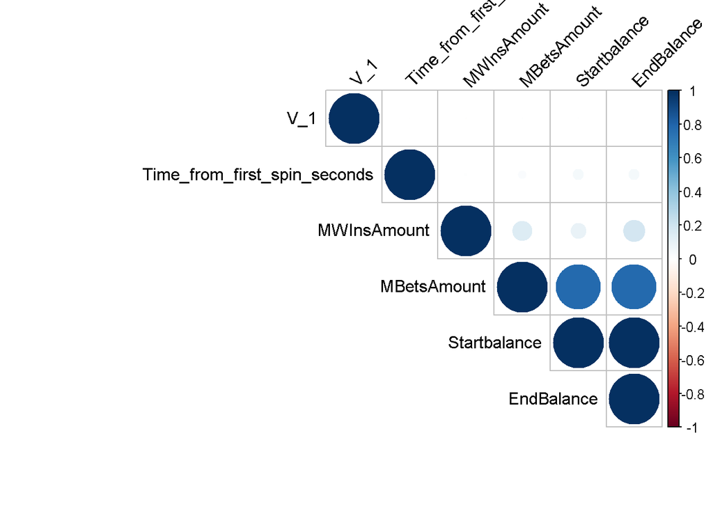

```r
corrplot(cor_matrix,
         type = "upper", order = "hclust",
         tl.col = "black", tl.srt = 45)
```

# Test-train split

Ideally, I would like to perform cross validation. However, the sheer size of the data is not forgiving on my poor laptop. Therefore, I resort to test-train split.

```r
#### test-train split ####
test_split_ratio <- 0.2
n_rows <- nrow(DATA_1)
train_sample_size <- floor((1-test_split_ratio)*n_rows)
## set seed for partition reproductibility
set.seed(42)
train_ind <- sample(seq_len(n_rows),
                    size=train_sample_size)

train_set <- DATA_1[train_ind, ]
test_set <- DATA_1[-train_ind, ]
```

## Base-line logistic regression

Next, run logistic regression on a few variable, as a base-line. These are only a handful, as this is trained locally (otherwise I run into memory issues).

```r
#### logistic regression on the basic model ####
fit <- glm(LABELS ~ Time_from_first_spin_seconds + Startbalance + MBetsAmount + V_1,
           data=train_set,
           family=binomial(link='logit'))

summary(fit)
```

```
##
## Call:
## glm(formula = LABELS ~ Time_from_first_spin_seconds + Startbalance +
##     MBetsAmount + V_1, family = binomial(link = "logit"), data = train_set)
##
## Deviance Residuals:
##     Min       1Q   Median       3Q      Max
## -3.6832  -1.2099   0.6401   1.1313   2.1414
##
## Coefficients:
##                                Estimate Std. Error z value Pr(>|z|)
## (Intercept)                   6.244e-02  6.547e-03   9.537   <2e-16 ***
## Time_from_first_spin_seconds  2.452e-05  1.647e-07 148.919   <2e-16 ***
## Startbalance                  6.057e-06  3.089e-07  19.608   <2e-16 ***
## MBetsAmount                  -5.293e-04  2.384e-05 -22.204   <2e-16 ***
## V_1                           6.174e-04  1.735e-03   0.356    0.722
## ---
## Signif. codes:  0 '***' 0.001 '**' 0.01 '*' 0.05 '.' 0.1 ' ' 1
##
## (Dispersion parameter for binomial family taken to be 1)
##
##     Null deviance: 618644  on 456135  degrees of freedom
## Residual deviance: 589055  on 456131  degrees of freedom
## AIC: 589065
##
## Number of Fisher Scoring iterations: 5
```

```r
fit_results <- predict(fit, type='response',
                       newdata=test_set)
fit_results <- ifelse(fit_results > 0.5,1,0)

accuracy <- mean(fit_results == DATA_1$LABELS)
print(paste('Accuracy:',round(accuracy, 3)))
```

```
## [1] "Accuracy: 0.584"
```

# Feature extraction

I then proceed to feature extraction.

These features are hand picked, in a somewhat arbitrary manner.

I created a weekday and hour factor. Possibly players act differently throughout the day and in different days.

I defined a `gift` variable as `EndBalance - Startbalance + MBetsAmount - MWInsAmount`. Whenever `EndBalance = Startbalance - MBetsAmount + MWinsAmount` does not hold, there is some external interference. I defined it as the `gift` variable.

The `MBetsAmount` variable is normalized to the magnitude of `Startbalance`.

A new variable, `log_Startbalance`, is created, as it is plausible to hypothesize that a player’s sensetivity to the balance is decreasing non-linearly.

```r
#### feature extraction ####
# get the weekday
DATA_1$weekdays <- as.factor(weekdays(DATA_1$TimeStamp))
# get the (decimal) hour
DATA_1$hour <- as.factor(format(DATA_1$TimeStamp,'%H'))
# we should *usually* get: EndBalance=Startbalance - MBetsAmount+MWinsAmount
# therefore, we can define the differences as "gifts"
DATA_1$gift <- with(DATA_1, EndBalance - Startbalance + MBetsAmount - MWInsAmount)
DATA_1$gift <- with(DATA_1, gift / Startbalance)
# possibly useful variables, normalizing "monetary" variables
DATA_1$MBetsAmount <- with(DATA_1, MBetsAmount / Startbalance)
DATA_1$log_Startbalance <- log(DATA_1$Startbalance)

# allocate test-train again
train_set <- DATA_1[train_ind, ]
test_set <- DATA_1[-train_ind, ]
all(names(DATA_1) == names(test_set))
```

```
## [1] TRUE
```

```r
describe(DATA_1$gift)  # very skewed, even after normalizing for start balance
```

```
##    vars      n mean   sd median trimmed mad   min   max range   skew
## X1    1 570170    0 0.21      0       0   0 -1.11 98.51 99.62 312.35
##    kurtosis se
## X1 120267.3  0
```

# Forward selection, based on AIC

As mentioned before, computing power is a real limitng force here.

Therefore, I limit the search here to 3 steps, i.e. a forward search of only 3 variables. Any more and I run out of memory! Had I was not limited by this factor, there are many more interesting interactions to explore, such as interactions between `GameID`, `PlatformID`, `IND_USER_ID`, `weekdays`, `hour` and the numeric variables.

I also omitted some of the balance variables from the search, due to the multi-colinearity in the data.

```r
#### forward selection ####
fit_forward <- glm(LABELS ~ 1,
                   data=train_set,
                   family=binomial(link='logit'))

step(fit_forward,
     direction='forward',
     steps=3,  # up to *steps* variables
     scope=~ GameID * (Time_from_first_spin_seconds + log_Startbalance
             + MBetsAmount + MWInsAmount + gift + V_1 + weekdays + hour))
```

```
## Start:  AIC=618645.8
## LABELS ~ 1
##
##                                Df Deviance    AIC
## + Time_from_first_spin_seconds  1   589888 589892
## + hour                         23   596864 596912
## + GameID                       30   605801 605863
## + weekdays                      6   608649 608663
## + log_Startbalance              1   612385 612389
## + MBetsAmount                   1   618543 618547
## + MWInsAmount                   1   618639 618643
## + gift                          1   618640 618644
## <none>                              618644 618646
## + V_1                           1   618644 618648
##
## Step:  AIC=589891.9
## LABELS ~ Time_from_first_spin_seconds
##
##                    Df Deviance    AIC
## + hour             23   582551 582601
## + GameID           30   583836 583900
## + log_Startbalance  1   586321 586327
## + weekdays          6   587253 587269
## + MBetsAmount       1   589482 589488
## + MWInsAmount       1   589878 589884
## <none>                  589888 589892
## + gift              1   589886 589892
## + V_1               1   589888 589894
##
## Step:  AIC=582600.7
## LABELS ~ Time_from_first_spin_seconds + hour
##
##                    Df Deviance    AIC
## + GameID           30   577236 577346
## + weekdays          6   577787 577849
## + log_Startbalance  1   579429 579481
## + MBetsAmount       1   582129 582181
## + MWInsAmount       1   582539 582591
## <none>                  582551 582601
## + gift              1   582549 582601
## + V_1               1   582551 582603
##
## Step:  AIC=577345.9
## LABELS ~ Time_from_first_spin_seconds + hour + GameID
```

```
##
## Call:  glm(formula = LABELS ~ Time_from_first_spin_seconds + hour +
##     GameID, family = binomial(link = "logit"), data = train_set)
##
## Coefficients:
##                  (Intercept)  Time_from_first_spin_seconds
##                   -9.545e-01                     2.613e-05
##                       hour01                        hour02
##                    1.258e+00                    -1.333e-01
##                       hour03                        hour04
##                    7.185e-01                     9.492e-01
##                       hour05                        hour06
##                    1.222e+00                     9.516e-01
##                       hour07                        hour08
##                    8.500e-01                     1.211e+00
##                       hour09                        hour10
##                    1.212e+00                     1.406e+00
##                       hour11                        hour12
##                    1.490e+00                     9.424e-01
##                       hour13                        hour14
##                    1.334e+00                     8.212e-01
##                       hour15                        hour16
##                    1.590e+00                     5.568e-01
##                       hour17                        hour18
##                    1.221e+00                     1.376e+00
##                       hour19                        hour20
##                    6.508e-01                     2.232e-02
##                       hour21                        hour22
##                    1.358e+00                     1.534e+00
##                       hour23                      GameID68
##                    4.935e-01                     2.076e+00
##                     GameID71                      GameID72
##                    7.254e-02                     2.749e-01
##                     GameID78                      GameID84
##                    1.015e+01                     1.263e+00
##                     GameID86                      GameID89
##                    4.397e-01                    -4.696e-01
##                     GameID91                      GameID94
##                    7.383e-01                    -1.330e-01
##                     GameID95                      GameID97
```

[output cut: 10 more lines]

```
##                   -4.566e-01                     8.383e-01
##                    GameID139                    GameID5005
##                   -7.875e-01                     1.020e+01
##                   GameID5010                    GameID5020
##                    5.307e-01                     1.180e-01
##                   GameID5026                    GameID5027
##                    1.482e-02                     1.046e+01
##                   GameID5041                    GameID5045
##                    1.003e-01                     8.494e-02
##                   GameID5050
##                   -1.200e-01
##
## Degrees of Freedom: 456135 Total (i.e. Null);  456081 Residual
## Null Deviance:       618600
## Residual Deviance: 577200    AIC: 577300
```

# Choose model

The model that achieved the minimal AIC, of the models search, is:

`LABELS ~ Time_from_first_spin_seconds + hour + GameID`

Results are not impressive, as we are no way near exhausting the potential of the data. I am, however, forced to stop due to very limited computing power.

```r
## chosen model formula
form <- LABELS ~ Time_from_first_spin_seconds + hour + GameID
fit_select <- glm(form,
                  data=DATA_1, family=binomial(link='logit'))

fit_results <- predict(fit_select, type='response')
fit_results <- ifelse(fit_results > 0.5,1,0)

accuracy <- mean(fit_results == DATA_1$LABELS)
print(paste('Accuracy:', round(accuracy, 3)))
```

```
## [1] "Accuracy: 0.62"
```

# ROC analysis

We see even more evidence for poor performance.

```r
#### ROC analysis ####
p <- predict(fit_select, type="response")
pr <- prediction(p, DATA_1$LABELS)
prf <- performance(pr, measure = "tpr", x.measure = "fpr")
# plot ROC, save to file
pdf(file.path(output_dir, 'roc.pdf'))
plot(prf)
abline(a=0, b= 1)
dev.off()
```

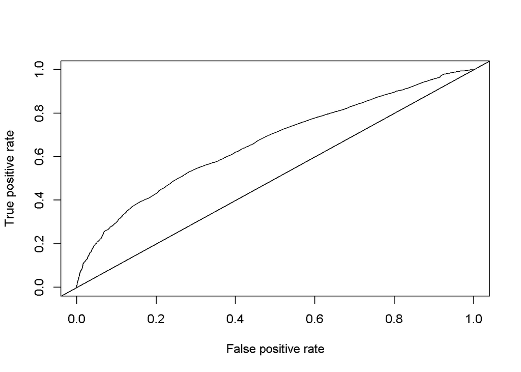

```r
plot(prf)
abline(a=0, b= 1)
```

```r
# calculate AUC metric
auc <- performance(pr, measure = "auc")
auc <- auc@y.values[[1]]
print(paste('AUC (Area Under the Curve):', round(auc, 3)))
```

```
## [1] "AUC (Area Under the Curve): 0.664"
```